# Finance Project Presentation

Power point slides for finance project presentation

He Qiyun https://example.com/norajones (SMU MITB (AI))https://scis.smu.edu.sg/  
2022-04-17

**The project choose two stocks for analysis:**

1. Contemporary Amperex Technology Co., Ltd (CATL)
2. Energy Very Endure Energy Co., Ltd. (EVE)

**The analysis is divided into three parts:**

1. Introduction(company products and competitive advantages)

[figure not shown]

2. Macroeconomic analysis

[figure not shown]

3. Financial Analysis

```
I'm in charge of financial analysis and will describe the slides made for the
presentation as shown below.
```

**Financial Analysis**

Financial statement information from year 2017-2020 are collected from eastmoney app as well as annual reports that can be found and downloaded from website: http://www.cninfo.com.cn/new/index

Information are collected and calculated using excel, graphs are then plotted using Tableau for easier viewing.

Overall, both company presents healthy financial statements,indicating high growth potential.

**1. Asset**

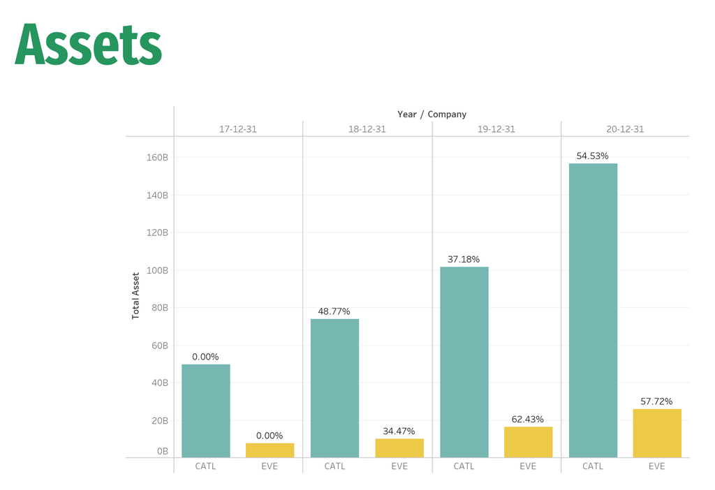

**2. Liability**

- Looking at liability information to understand if the company has insolvency risk.
  - Liabilities 1
    - Total Liabilities:
      - CATL has higher liability than EVE, this is not suprising considering its much larger asset volume.
    - Liability-Asset ratio:
      - Both companies has a positive ratio in a healthy range of 35%-65%.
    - Current ratio:
      - Both companies has a positive ratio >1.

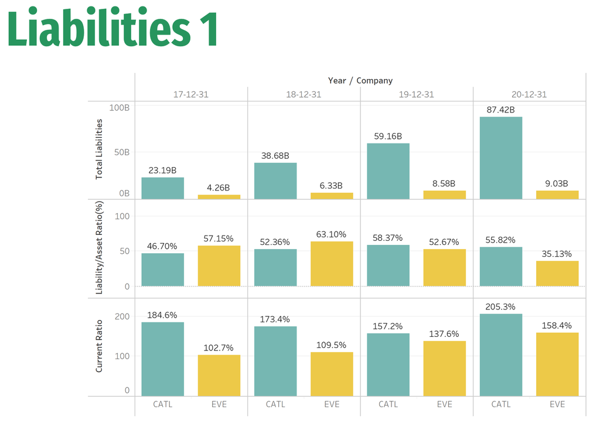

- Liabilities 2
  - Cash and cash equivalents & cash/total assets
    - Both companies have positive cash, with CATL having higher % of assets in cash, indicating higher debt-paying ability.
  - Cash and cash equivalents - interest bearing liabilities
    - Same as above, with higher value, CATL has lower default risk.

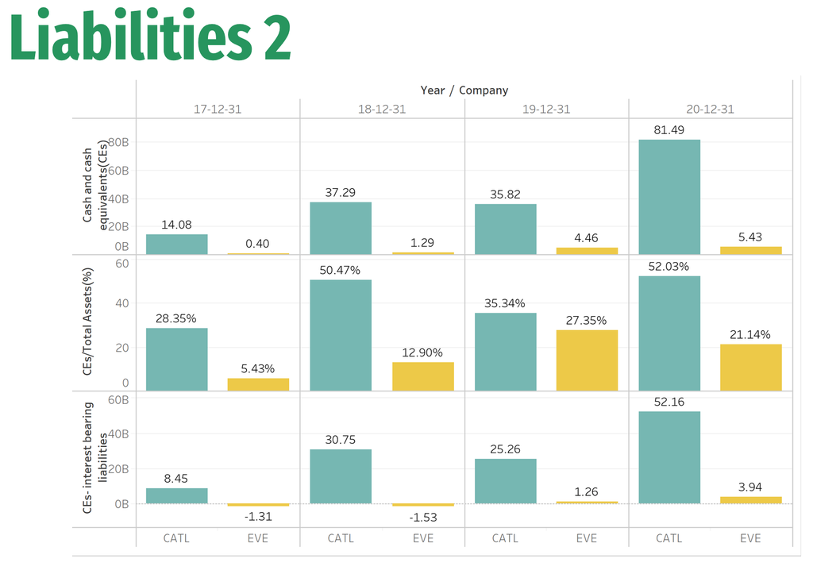

**3. Product**

- Price Negotiation Power
  - Difference
    - Difference = (Accounts payable + Advanced Payment Received) - (Accounts Receivable + Advanced Payment)
    - Positive value suggests that the company’s product is competitive, giving it a higher price negotiation power
    - CATL has a much larger positive value than EVE, this makes sense as it is the leading company in the industry.
  - Accounts Receivable/Total Asset
    - This percentage should not be very high as a high value means that the company may have difficulty selling its product, suggesting lower product competitiveness.
    - The percentage for both company are low, below 20%.
    - EVE has a higher percentage, indicating lower product competitiveness.

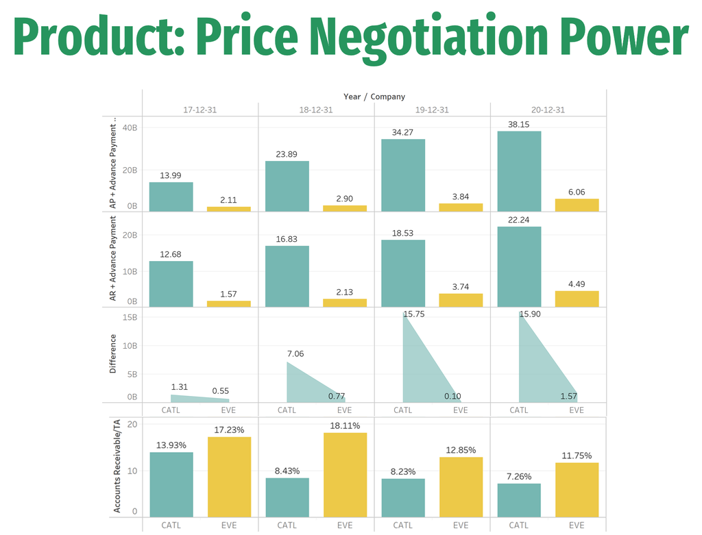

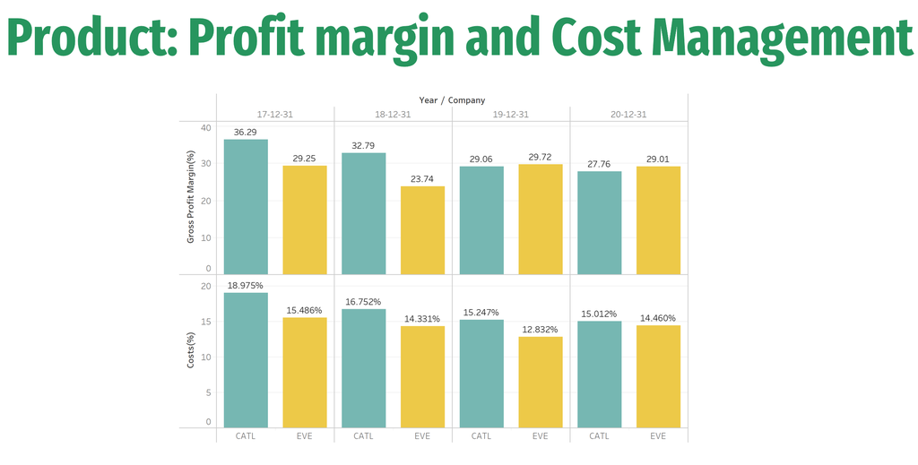

**4. Net Profit**

- Profit for parent company’s owners
  - Net Profit
    - Both companies have positive increasing values from 2018 onwards.
    - The values for CATL is much higher than EVE.

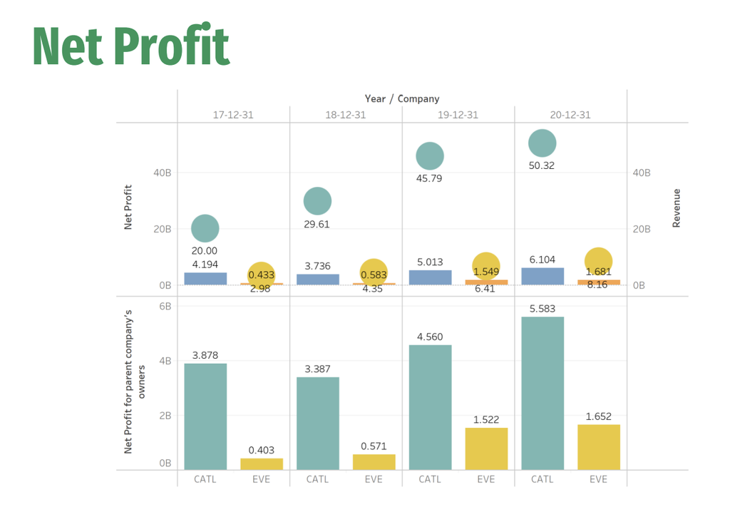

**5. Other Ratios**

- P/E
  - The high values indicate that both companies are overvalued.
- ROE
  - EVE has higher ROE than CATL from 2018 onwards, this is a bit suprising given CATL’s better performance in other areas.

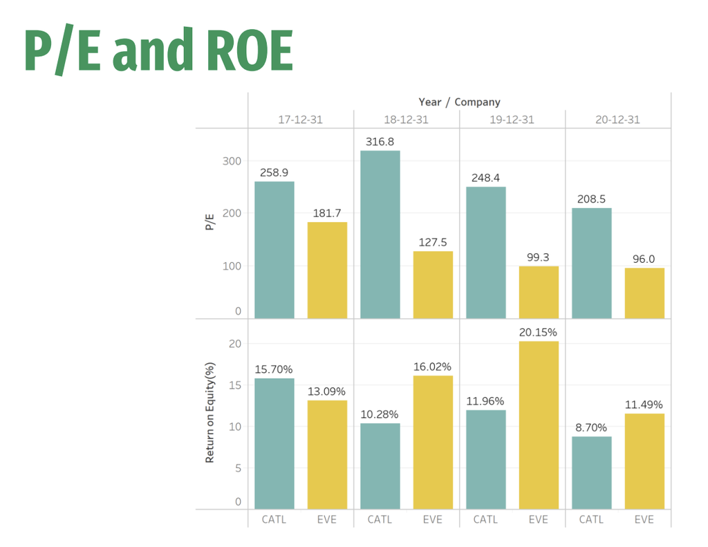